# Project 7: Difference-in-Differences and Synthetic Control

Cindy Alvarez

```r
# Install and load packages
if (!require("pacman")) install.packages("pacman")
devtools::install_github("ebenmichael/augsynth")
```

```r
pacman::p_load(# Tidyverse packages including dplyr and ggplot2
               tidyverse,
               ggthemes,
               augsynth,
               gsynth,
               ggplot2,
               multiSynth)
#
# chunk options
# ----------------------------------------------------------------
knitr::opts_chunk$set(
  warning = FALSE            # prevents warning from appearing after code chunk
)

# set seed
set.seed(44)

# load data
medicaid_expansion <- read_csv('data/medicaid_expansion.csv')
```

# Introduction

For this project, you will explore the question of whether the Affordable Care Act increased health insurance coverage (or conversely, decreased the number of people who are uninsured). The ACA was passed in March 2010, but several of its provisions were phased in over a few years. The ACA instituted the “individual mandate” which required that all Americans must carry health insurance, or else suffer a tax penalty. There are four mechanisms for how the ACA aims to reduce the uninsured population:

- Require companies with more than 50 employees to provide health insurance.
- Build state-run healthcare markets (“exchanges”) for individuals to purchase health insurance.
- Provide subsidies to middle income individuals and families who do not qualify for employer based coverage.
- Expand Medicaid to require that states grant eligibility to all citizens and legal residents earning up to 138% of the federal poverty line. The federal government would initially pay 100% of the costs of this expansion, and over a period of 5 years the burden would shift so the federal government would pay 90% and the states would pay 10%.

In 2012, the Supreme Court heard the landmark case NFIB v. Sebelius, which principally challenged the constitutionality of the law under the theory that Congress could not institute an individual mandate. The Supreme Court ultimately upheld the individual mandate under Congress’s taxation power, but struck down the requirement that states must expand Medicaid as impermissible subordination of the states to the federal government. Subsequently, several states refused to expand Medicaid when the program began on January 1, 2014. This refusal created the “Medicaid coverage gap” where there are indivudals who earn too much to qualify for Medicaid under the old standards, but too little to qualify for the ACA subsidies targeted at middle-income individuals.

States that refused to expand Medicaid principally cited the cost as the primary factor. Critics pointed out however, that the decision not to expand primarily broke down along partisan lines. In the years since the initial expansion, several states have opted into the program, either because of a change in the governing party, or because voters directly approved expansion via a ballot initiative.

You will explore the question of whether Medicaid expansion reduced the uninsured population in the U.S. in the 7 years since it went into effect. To address this question, you will use difference-in-differences estimation, and synthetic control.

# Data

The dataset you will work with has been assembled from a few different sources about Medicaid. The key variables are:

- **State**: Full name of state
- **Medicaid Expansion Adoption**: Date that the state adopted the Medicaid expansion, if it did so.
- **Year**: Year of observation.
- **Uninsured rate**: State uninsured rate in that year.

# Exploratory Data Analysis

Create plots and provide 1-2 sentence analyses to answer the following questions:

- Which states had the highest uninsured rates prior to 2014? The lowest?
- Which states were home to most uninsured Americans prior to 2014? How about in the last year in the data set? **Note**: 2010 state population is provided as a variable to answer this question. In an actual study you would likely use population estimates over time, but to simplify you can assume these numbers stay about the same.

```r
# highest and lowest uninsured rates

summary(medicaid_expansion)
```

```
##     State            Date_Adopted             year      uninsured_rate
##  Length:663         Min.   :2014-01-01   Min.   :2008   Min.   :0.02495
##  Class :character   1st Qu.:2014-01-01   1st Qu.:2011   1st Qu.:0.07702
##  Mode  :character   Median :2014-01-01   Median :2014   Median :0.10475
##                     Mean   :2014-11-30   Mean   :2014   Mean   :0.10978
##                     3rd Qu.:2014-09-18   3rd Qu.:2017   3rd Qu.:0.13888
##                     Max.   :2020-10-01   Max.   :2020   Max.   :0.24082
##                     NA's   :195
##    population
##  Min.   :  584153
##  1st Qu.: 1850326
##  Median : 4531566
##  Mean   : 6364343
##  3rd Qu.: 7061530
##  Max.   :38802500
##  NA's   :13
```

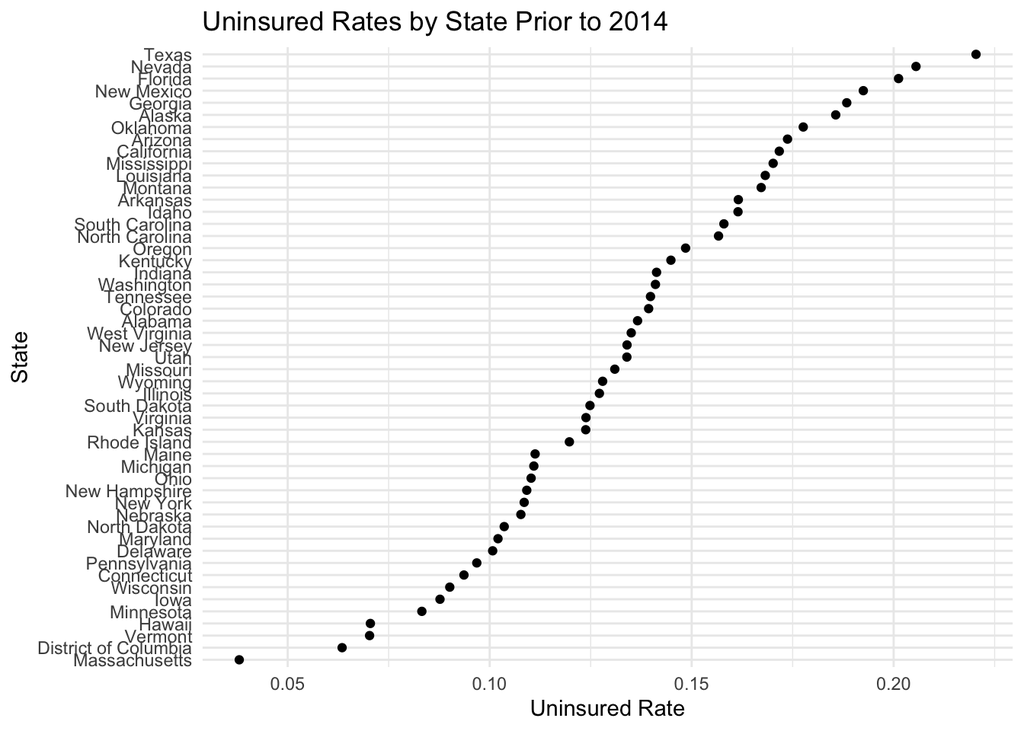

```r
# Filter data for years prior to 2014 and find the latest year for each state
pre_2014 <- medicaid_expansion %>%
  filter(year < 2014) %>%
  group_by(State) %>%
  arrange(desc(year)) %>%
  slice(1) %>%
  ungroup()

# Plot states by uninsured rates (prior to 2014)
pre_2014 %>%
  arrange(uninsured_rate) %>%
  mutate(State = factor(State, levels = State)) %>%
  ggplot(aes(x = uninsured_rate, y = State)) +
  geom_point() +
  labs(title = "Uninsured Rates by State Prior to 2014",
       x = "Uninsured Rate",
       y = "State") +
  theme_minimal()
```

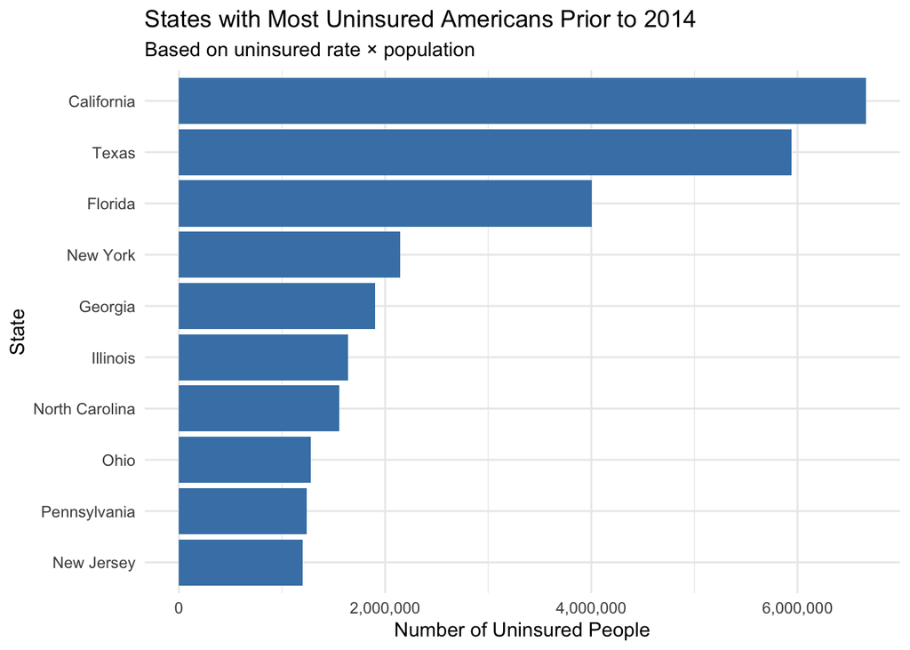

```r
# most uninsured Americans

# Calculate the number of uninsured people in each state
# Using the population data consistently for all calculations
medicaid_with_counts <- medicaid_expansion %>%
  mutate(uninsured_count = uninsured_rate * population)

# For pre-2014: Which states were home to most uninsured Americans?
pre_2014_counts <- medicaid_with_counts %>%
  filter(year < 2014) %>%
  group_by(State) %>%
  arrange(desc(year)) %>%
  slice(1) %>%  # Take the most recent year for each state before 2014
  ungroup() %>%
  arrange(desc(uninsured_count)) %>%
  slice_head(n = 10)  # Top 10 states

# For the last year: Which states were home to most uninsured Americans?
last_year <- max(medicaid_expansion$year)
last_year_counts <- medicaid_with_counts %>%
  filter(year == last_year) %>%
  arrange(desc(uninsured_count)) %>%
  slice_head(n = 10)  # Top 10 states

# Create a plot for pre-2014 counts
ggplot(pre_2014_counts, aes(x = reorder(State, uninsured_count), y = uninsured_count)) +
  geom_col(fill = "steelblue") +
  coord_flip() +
  labs(title = "States with Most Uninsured Americans Prior to 2014",
       subtitle = "Based on uninsured rate × population",
       x = "State",
       y = "Number of Uninsured People") +
  scale_y_continuous(labels = scales::comma) +
  theme_minimal()
```

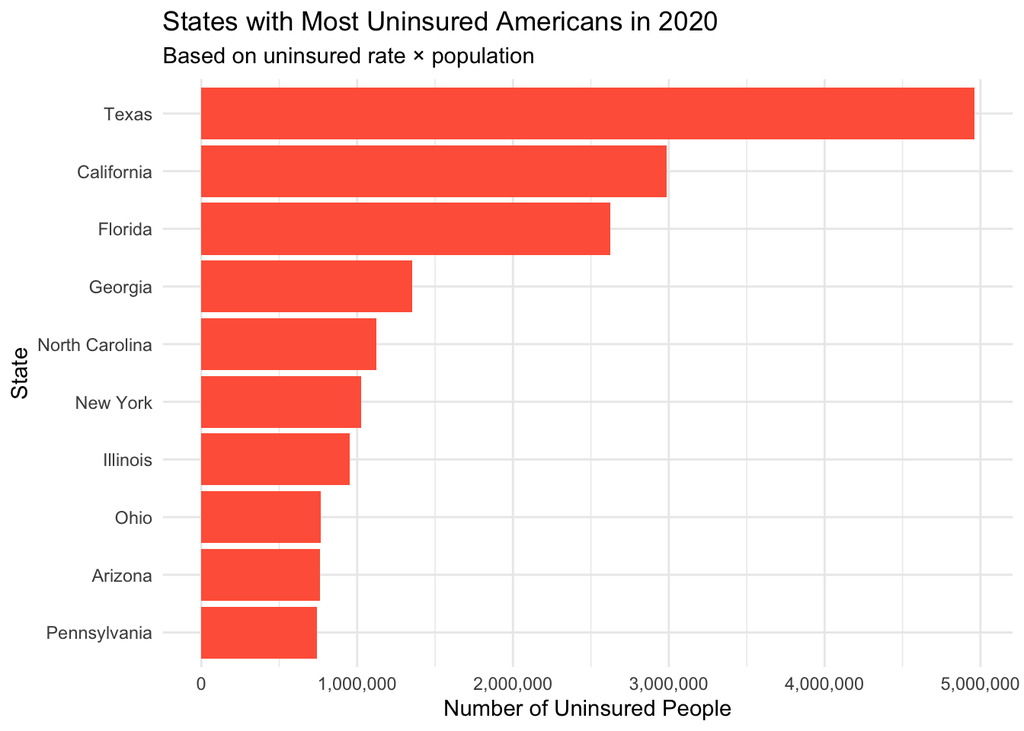

```r
# Create a plot for last year counts
ggplot(last_year_counts, aes(x = reorder(State, uninsured_count), y = uninsured_count)) +
  geom_col(fill = "tomato") +
  coord_flip() +
  labs(title = paste("States with Most Uninsured Americans in", last_year),
       subtitle = "Based on uninsured rate × population",
       x = "State",
       y = "Number of Uninsured People") +
  scale_y_continuous(labels = scales::comma) +
  theme_minimal()
```

# Difference-in-Differences Estimation

## Estimate Model

Do the following:

- Choose a state that adopted the Medicaid expansion on January 1, 2014 and a state that did not. **Hint**: Do not pick Massachusetts as it passed a universal healthcare law in 2006, and also avoid picking a state that adopted the Medicaid expansion between 2014 and 2015.
- Assess the parallel trends assumption for your choices using a plot. If you are not satisfied that the assumption has been met, pick another state and try again (but detail the states you tried).

```r
# Parallel Trends plot

# Select state that adopted Medicaid expansion on 1/1/2014
medicaid_expansion %>%
  filter(Date_Adopted == "2014-01-01") # filter states to those that adopted on 1/1/2014
```

```
## # A tibble: 325 × 5
##    State                Date_Adopted  year uninsured_rate population
##    <chr>                <date>       <dbl>          <dbl>      <dbl>
##  1 Arizona              2014-01-01    2008         0.187     6731484
##  2 Arkansas             2014-01-01    2008         0.179     2994079
##  3 California           2014-01-01    2008         0.178    38802500
##  4 Colorado             2014-01-01    2008         0.170     5355856
##  5 Connecticut          2014-01-01    2008         0.0891    3596677
##  6 Delaware             2014-01-01    2008         0.108      935614
##  7 District of Columbia 2014-01-01    2008         0.0805         NA
##  8 Hawaii               2014-01-01    2008         0.0672    1419561
##  9 Illinois             2014-01-01    2008         0.129    12880580
## 10 Iowa                 2014-01-01    2008         0.0873    3107126
## # ℹ 315 more rows
```

```r
# Connecticut will be my first treatment state, adopting Medicaid on 1/1/2014

# Select state that did not adopt Medicaid expansion on 1/1/2014 (or between 2014 and 2015)

medicaid_expansion %>%
  filter(Date_Adopted != "2014-01-01")
```

```
## # A tibble: 143 × 5
##    State         Date_Adopted  year uninsured_rate population
##    <chr>         <date>       <dbl>          <dbl>      <dbl>
##  1 Alaska        2015-09-01    2008         0.208      737732
##  2 Idaho         2020-01-01    2008         0.176     1634464
##  3 Indiana       2015-02-01    2008         0.138     6596855
##  4 Louisiana     2016-07-01    2008         0.179     4649676
##  5 Michigan      2014-04-01    2008         0.115     9909877
##  6 Montana       2016-01-01    2008         0.189     1023579
##  7 Nebraska      2020-10-01    2008         0.108     1881503
##  8 New Hampshire 2014-08-15    2008         0.110     1326813
##  9 Pennsylvania  2015-01-01    2008         0.0960   12787209
## 10 Utah          2020-01-01    2008         0.241     2942902
## # ℹ 133 more rows
```

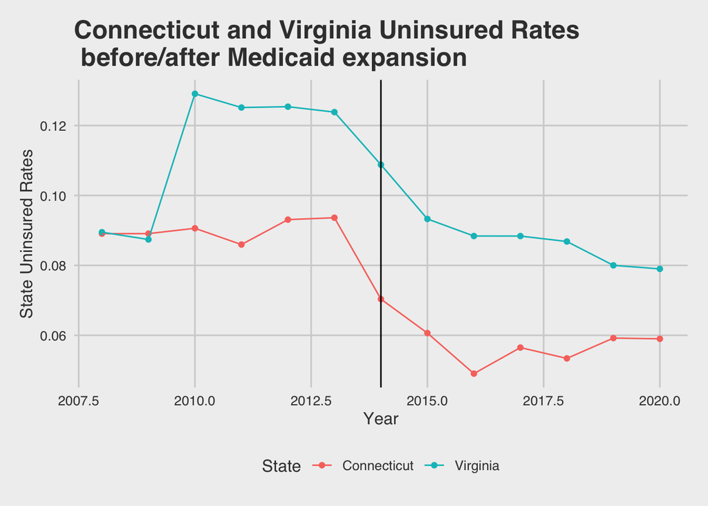

```r
# Virginia will be my first control state, it adopted on 1/1/2019

medicaid_expansion %>%

  # process
  # ---------
  filter(State %in% c("Connecticut","Virginia")) %>%
  # plotting all of the time periods -- not filtering out any of them

  # plot
  # ---------
  ggplot() +
  # add in point layer
  geom_point(aes(x = year,
                 y = uninsured_rate,
                 color = State)) +
  # add in line layer
  geom_line(aes(x = year,
                y = uninsured_rate,
                color = State)) +
  # add a horizontal line
  geom_vline(aes(xintercept = 2014)) +

  # themes
  theme_fivethirtyeight() +
  theme(axis.title = element_text()) +

  # labels
  ggtitle('Connecticut and Virginia Uninsured Rates \n before/after Medicaid expansion') +
  xlab('Year') +
  ylab('State Uninsured Rates')
```

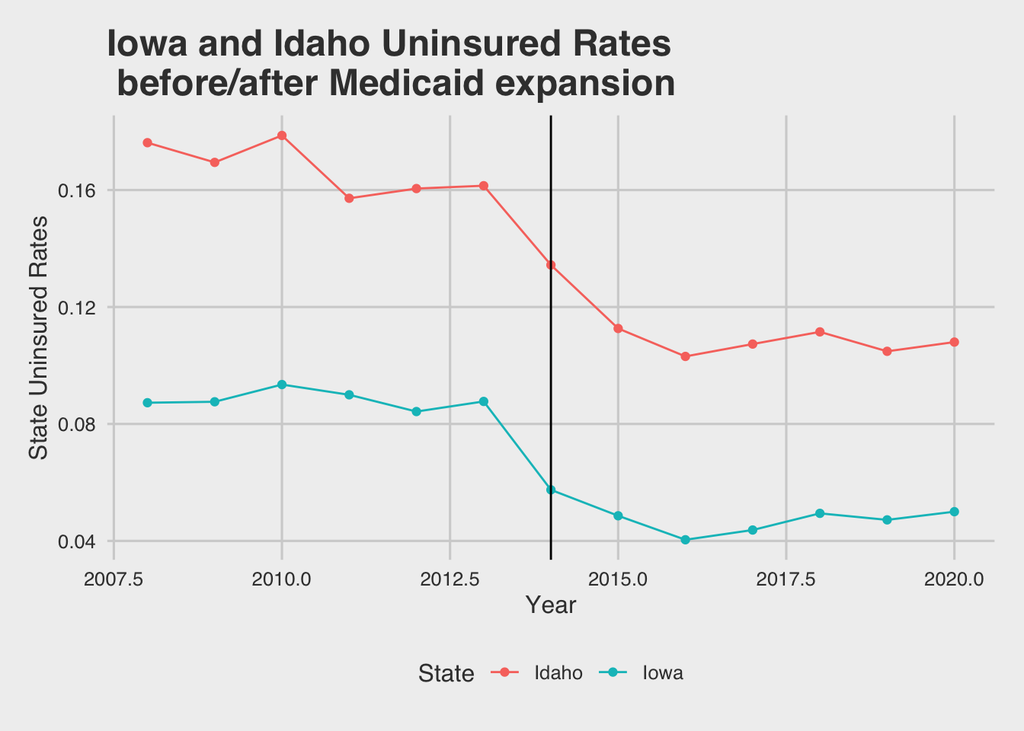

```r
# Parallel trends between Connecticut and Virginia were not satisfied. Selecting a new pair of states to try.

# Iowa and Idaho:

medicaid_expansion %>%

  # process
  # ---------
  filter(State %in% c("Iowa","Idaho")) %>%
  # plotting all of the time periods -- not filtering out any of them

  # plot
  # ---------
  ggplot() +
  # add in point layer
  geom_point(aes(x = year,
                 y = uninsured_rate,
                 color = State)) +
  # add in line layer
  geom_line(aes(x = year,
                y = uninsured_rate,
                color = State)) +
  # add a horizontal line
  geom_vline(aes(xintercept = 2014)) +

  # themes
  theme_fivethirtyeight() +
  theme(axis.title = element_text()) +

  # labels
  ggtitle('Iowa and Idaho Uninsured Rates \n before/after Medicaid expansion') +
  xlab('Year') +
  ylab('State Uninsured Rates')
```